# R Notebook

# For GEO Data https://www.ncbi.nlm.nih.gov/geo/query/acc.cgi?acc=GSM6568672

# Following this protocol: Joint RNA and ATAC Analysis: 10x Multiomic https://stuartlab.org/signac/articles/pbmc_multiomic

#1 Set up environment #1.1 Install any packages that you may need

```r
BiocManager::install("BSgenome.Mmusculus.UCSC.mm10")
n
```

#1.2 Load libraries you already have

```r
library(Seurat)
library(GenomicRanges)
library(Signac)
library(EnsDb.Mmusculus.v75)
library(BSgenome.Mmusculus.UCSC.mm10)
```

#2 Read in the .h5 RNA file (has snATAC and scRNA included)

```r
# In the fragment path you will need to also have an index file, I explain how to get that further below
so.1 <- Read10X_h5('/Users/christinacomo/Library/CloudStorage/OneDrive-TheUniversityofColoradoDenver/10xVisium/Sophia/data/GSM6568675_WT_1_RNA_filtered_feature_bc_matrix.h5')
```

```
Genome matrix has multiple modalities, returning a list of matrices for this genome
```

#2.1 Set up the directory to where the fragments.tsv.gz file is plus the indexed fragments file

```r
frag.path <- '/Users/christinacomo/Library/CloudStorage/OneDrive-TheUniversityofColoradoDenver/10xVisium/Sophia/data/GSM6568674_WT_1_atac_fragments.tsv.gz'
```

#3 Get the mouse annotation data so that we can annotate the snATAC genes

```r
# extract gene annotations from EnsDb
library(EnsDb.Mmusculus.v75)
annotations <- GetGRangesFromEnsDb(ensdb = EnsDb.Mmusculus.v75)
```

[output not shown]

[output not shown]

[output cut: 8 more lines]

[output not shown]

#3.1 We need to change the annotation file to UCSC style, because right now it does not have chr in front of the chromosome number

```r
# get gene annotations for mouse
# change to UCSC style since the data was mapped to hg19
seqlevels(annotations) <- paste0('chr', seqlevels(annotations))
genome(annotations) <- "mm10"
head(annotations)
```

```
GRanges object with 6 ranges and 5 metadata columns:
                     seqnames          ranges strand |              tx_id   gene_name            gene_id   gene_biotype     type
                        <Rle>       <IRanges>  <Rle> |        <character> <character>        <character>    <character> <factor>
  ENSMUSE00001251043     chr3 3508030-3508332      + | ENSMUST00000017832       Hnf4g ENSMUSG00000017688 protein_coding     exon
  ENSMUSE00001236884     chr3 3508030-3508332      + | ENSMUST00000108393       Hnf4g ENSMUSG00000017688 protein_coding     exon
  ENSMUSE00000676606     chr3 3634150-3634347      + | ENSMUST00000108394       Hnf4g ENSMUSG00000017688 protein_coding     exon
  ENSMUSE00001225938     chr3 3638059-3638230      + | ENSMUST00000017832       Hnf4g ENSMUSG00000017688 protein_coding     exon
  ENSMUSE00001298664     chr3 3638059-3638230      + | ENSMUST00000108393       Hnf4g ENSMUSG00000017688 protein_coding     exon
  ENSMUSE00001225938     chr3 3638059-3638230      + | ENSMUST00000108394       Hnf4g ENSMUSG00000017688 protein_coding     exon
  -------
  seqinfo: 22 sequences (1 circular) from mm10 genome
```

#4 Create the seurat object and chromatin assay for the ATAC and RNAseq assays

```r
# had to run the following commands in terminal to get a fragements index file :
  # tabix -p bed GSM6568678_WT_3_atac_fragments.tsv.gz

# create a Seurat object containing the RNA adata
so <- CreateSeuratObject(
  counts = so.1$`Gene Expression`,
  assay = "RNA"
)

# create ATAC assay and add it to the object
so[["ATAC"]] <- CreateChromatinAssay(
  counts = so.1$Peaks,
  sep = c(":", "-"),
  fragments = frag.path,
  annotation = annotations
)
```

```
Computing hash
Checking for 8919 cell barcodes
```

```r
so
```

```
An object of class Seurat
153920 features across 8919 samples within 2 assays
Active assay: RNA (32285 features, 0 variable features)
 1 layer present: counts
 1 other assay present: ATAC
```

```r
DefaultAssay(so) <- "ATAC"

so <- NucleosomeSignal(so)
```

[output not shown]

```r
so <- TSSEnrichment(so)
```

```
Extracting TSS positions
Extracting fragments at TSSs
```

[output not shown]

```
Computing TSS enrichment score
```

[figure not shown]

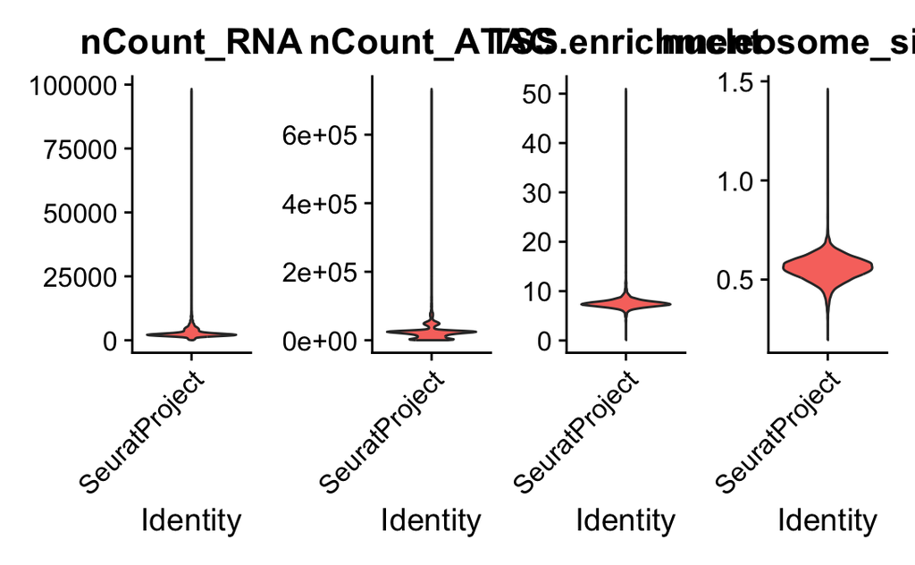

```r
# Use this violin plot to help remove any cells you dont want
VlnPlot(
  object = so,
  features = c("nCount_RNA", "nCount_ATAC", "TSS.enrichment", "nucleosome_signal"),
  ncol = 4,
  pt.size = 0
)
```

```r
# filter out low quality cells
so <- subset(
  x = so,
  subset = nCount_ATAC < 100000 &
    nCount_RNA < 25000 &
    nCount_ATAC > 1500 &
    nCount_RNA > 1000 &
    nucleosome_signal < 1 &
    TSS.enrichment > 1
)
so
```

```
An object of class Seurat
153920 features across 8013 samples within 2 assays
Active assay: ATAC (121635 features, 0 variable features)
 2 layers present: counts, data
 1 other assay present: RNA
```

```r
# Switch assay to RNA to process data via SCT. SCT does the normalization, scaling, finding neighbors/clusters
DefaultAssay(so) <- "RNA"
so <- SCTransform(so)
```

[output not shown]

[output cut: 446 more lines]

[output not shown]

```r
so <- RunPCA(so)
```

```
PC_ 1
Positive:  Cd74, Lyz2, H2-Aa, H2-Ab1, Igkc, Apoe, Ebf1, Ifitm3, Ly6d, Arhgap15
       Cybb, Cd79a, Plac8, H2-D1, Ccr2, S100a4, Crip1, Cd52, Ccl5, Itga4
       Ifitm2, mt-Co1, Tmsb10, Trps1, S100a6, Aff3, Nedd9, Vim, Iqgap1, Fxyd5
Negative:  Hexb, Csmd3, Plxdc2, Tanc2, Nav3, Nav2, P2ry12, C1qa, Cst3, C1qb
       C1qc, Sparc, Srgap2, Ctsd, Zfhx3, Tgfbr1, Siglech, Mertk, Epb41l2, Gpr34
       Dock4, Qk, Ctss, Mir99ahg, Ldlrad4, Trem2, Fcrls, Frmd4a, Elmo1, Pde3b
PC_ 2
Positive:  Lyz2, Apoe, Ifitm3, Cybb, Ifitm2, Adgre4, Trps1, Pf4, Mrc1, Cebpb
       Ace, Plac8, Fgr, Pla2g7, Ccr2, Cd44, Ifitm6, Gda, Nr4a1, Itga4
       Plbd1, F13a1, H2-D1, Apoc2, Gsr, Itgal, Gpr141, Ldlrad3, Clec4a1, Adgre5
Negative:  Igkc, Ebf1, Ly6d, Cd79a, Vpreb3, Aff3, Ms4a1, Iglc1, Iglc2, Cd79b
       Iglc3, Agbl1, Pax5, Ptprcap, Ikzf3, Chchd10, Bach2, Fcrla, Ighm, Tmem163
       Kcnq5, Cd24a, Gm30211, Cd72, mt-Co1, Siglecg, Tmsb10, Fam129c, Btla, Cd74
PC_ 3
Positive:  Ccl5, Nkg7, Ms4a4b, Skap1, Gzma, Trbc2, Gm2682, AW112010, Gimap4, Ly6c2
       Cd3g, Xcl1, Lgals1, Trbc1, Ctla2a, Ccnd2, Tmsb10, Id2, Cxcr6, Gzmb
       Cd3d, Klrb1c, Klrk1, Cd52, Il2rb, Itk, S100a10, S100a6, Cd226, Ptprcap
Negative:  Cd74, H2-Aa, H2-Ab1, Apoe, Igkc, Lyz2, Ebf1, Ly6d, Cd79a, Mrc1
       Pf4, Ms4a1, Ms4a7, F13a1, Dab2, Iglc2, Vpreb3, Iglc1, Cd79b, Iglc3
       Aff3, Agbl1, Ccr2, Pax5, Mgl2, Rbpj, H2-DMa, Cd209a, Clec10a, Ifi30
PC_ 4
Positive:  H2-Aa, Cd74, H2-Ab1, Ccl5, Nkg7, Apoe, Ms4a4b, Gzma, Skap1, Lgals1
       Trbc2, Gm2682, AW112010, Cd209a, Gimap4, Mrc1, Klrd1, Klrk1, Pf4, S100a10
       Cd3g, Ctla2a, Xcl1, Trbc1, Id2, Ccr2, Mgl2, Gzmb, S100a6, Grap2
Negative:  Lyz2, Ebf1, Igkc, Ly6d, Cybb, Cd79a, Ifitm3, Adgre4, Vpreb3, Ace
       Cebpb, Plac8, Fgr, Nedd9, Cd44, Nr4a1, Ifitm6, Apoc2, Ifitm2, Ldlrad3
       Gda, Ms4a1, Itga4, Adgre5, Gsr, Itgal, Aff3, Cytip, Treml4, Msrb1
PC_ 5
Positive:  H2-Aa, Cd74, H2-Ab1, Plac8, Ccr2, S100a4, Ifitm3, Plbd1, Crip1, Alcam
       Adgre4, Napsa, S100a6, Vim, Fxyd5, Ifitm2, Ace, Lgals3, Fgr, Adgre5
       Cd44, Gm15987, Ifitm6, Cybb, Gpr141, Nr4a1, Cd209a, Klf4, Cebpb, Gda
Negative:  Apoe, Pf4, Mrc1, F13a1, Ms4a7, Dab2, Rbpj, Ebf1, Aoah, Cd163
       Itsn1, Stab1, Colec12, Ccl5, Myo5a, Cp, Igf1, Clec10a, Vpreb3, Gm4951
       Igkc, Psd3, Ly6d, Cd79a, Cmah, Ctsc, Cd63, Folr2, Dse, Gzma
```

```r
DefaultAssay(so) <- "ATAC"
so <- FindTopFeatures(so, min.cutoff = 5)
so <- RunTFIDF(so)
```

```
Performing TF-IDF normalization
```

```r
so <- RunSVD(so)
```

```
Running SVD
Scaling cell embeddings
```

```r
# build a joint UMAP visualization
so <- RunUMAP(
  object = so,
  nn.name = "weighted.nn",
  assay = "RNA",
  verbose = TRUE
)
```

```
Found more than one class "dist" in cache; using the first, from namespace 'spam'
Also defined by 'BiocGenerics'
Using method 'umap'
```

```r
# build a joint UMAP visualization
so <- RunUMAP(
  object = so,
  nn.name = "weighted.nn",
  assay = "RNA",
  verbose = TRUE
)
```

```
Found more than one class "dist" in cache; using the first, from namespace 'spam'
Also defined by 'BiocGenerics'
Using method 'umap'
```

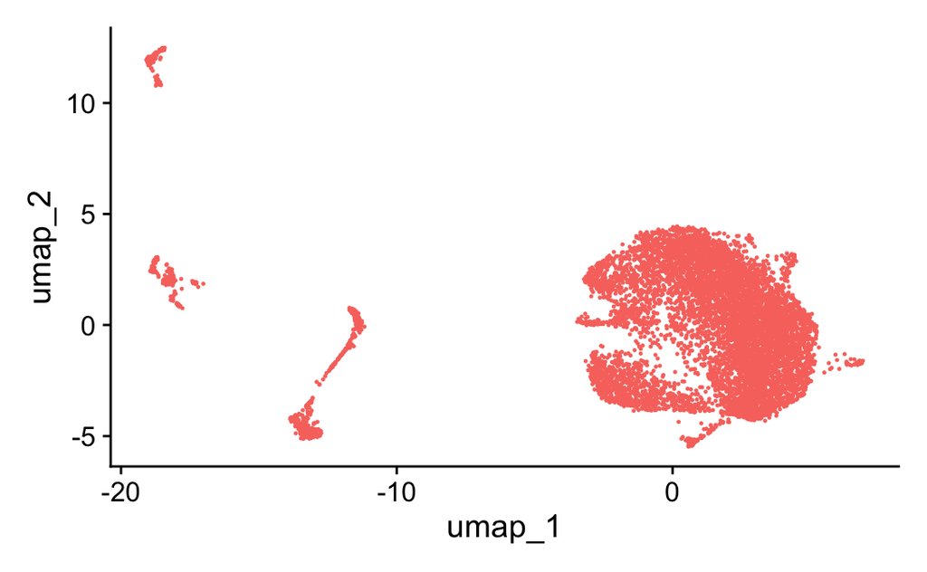

```r
DimPlot(so, label = TRUE, repel = TRUE, reduction = "umap") + NoLegend()
```

```r
so <- FindClusters(so, resolution = 0.2)
```

```
Modularity Optimizer version 1.3.0 by Ludo Waltman and Nees Jan van Eck

Number of nodes: 8013
Number of edges: 262548

Running Louvain algorithm...
```

```
Maximum modularity in 10 random starts: 0.9111
Number of communities: 9
Elapsed time: 0 seconds
```

```r
so <- FindClusters(so, resolution = 0.2)
```

```
Modularity Optimizer version 1.3.0 by Ludo Waltman and Nees Jan van Eck

Number of nodes: 8013
Number of edges: 262548

Running Louvain algorithm...
```

```
Maximum modularity in 10 random starts: 0.9111
Number of communities: 9
Elapsed time: 0 seconds
```

```r
so <- RunUMAP(so, dims = 1:10)
```

```
Found more than one class "dist" in cache; using the first, from namespace 'spam'
Also defined by 'BiocGenerics'
Found more than one class "dist" in cache; using the first, from namespace 'spam'
Also defined by 'BiocGenerics'
Using method 'umap'
```

[figure not shown]

```r
saveRDS(so, '/Users/christinacomo/Library/CloudStorage/OneDrive-TheUniversityofColoradoDenver/10xVisium/Sophia/so.RDS')
so <- readRDS('/Users/christinacomo/Library/CloudStorage/OneDrive-TheUniversityofColoradoDenver/10xVisium/Sophia/so.RDS')
```

# I recommend finding the cellular cluster you are interested in in each sample and then subsetting it. Then, merge the subsetted data into one. This will allow a lot faster processing instead of trying to merge all samples into one with all cellular clusters.

# It looks like cluster 4 is bam-1 according to the paper.

[figure not shown]

[figure not shown]

[figure not shown]